# National precipitation isotope data processing

Author

Bruce Dudley

Published

July 8, 2025

# 1 Read in output from previous runs of this code

```r
# Setup chunk — load processed climate data
output_dir <- "output"
rds_files <- list.files(output_dir, pattern = "^vcsn_data_.*\\.rds$", full.names = TRUE)

# Load into a named list, named by site
climate_data_all_sites <- lapply(rds_files, readRDS)

# Replace underscores with spaces in names to match isotope Site_Name format
site_names <- gsub("^vcsn_data_|\\.rds$", "", basename(rds_files))
site_names_spaces <- gsub("_", " ", site_names)

names(climate_data_all_sites) <- site_names_spaces
```

# 2 Read in and check first raw dataset

We’ll start with the McDonnell dataset and do a few checks on our methods

### 2.0.1 Read in data

```r
library(readxl)

# Read in the lookup table and sub-daily data
lookup_table <- read_excel("JeffMcD.xlsx", sheet = "SITE DATA lookup")
lookup_table<- lookup_table %>% dplyr::rename(lon = long)
ddata <- read_excel("JeffMcD.xlsx", sheet = "DATA")
dates<-read.csv('dates.csv')
```

### 2.0.2 Add lats and longs from lookup to main dataframe

```r
library(dplyr)

# Join long and lat from lookup_table into sub_daily_data
ddata <- ddata %>%
  left_join(
    lookup_table %>% select(Site_Name, lon, lat),
    by = "Site_Name"
  )
```

### 2.0.3 Amount weighting

```r
daily_data <- ddata %>%
  mutate(Date = as.Date(Collection_Date_Time)) %>%
  group_by(Institution, Project, Site_Name, SampleID, Date, Collector_type, lon, lat) %>%
  summarise(
    daily_precip = sum(Precipitation_mm, na.rm = TRUE),
    d2H = {
      valid <- Precipitation_mm > 0 & !is.na(d2H)
      total_weight <- sum(Precipitation_mm[valid], na.rm = TRUE)
      if (total_weight > 0) {
        sum(d2H[valid] * Precipitation_mm[valid], na.rm = TRUE) / total_weight
      } else {
        NA_real_
      }
    },
    d18O = NA_real_,  # Add empty column for compatibility
    .groups = "drop"
  ) %>%
  rename(Precipitation_mm = daily_precip)
```

# 3 Import VCSN data

Now, for checking, we’ll bring in the Virtual Climate Station Network (VCSN) data from the nearest grid point. We’re most interested in daily rain data, because we’ll need that to do rain weighting at sites without rainfall amount measurements.

### 3.0.1 Load the VCSN data folder

```r
VCSN.directory <- "C:/Users/dudleybd/OneDrive - NIWA/Desktop/Precip isotope model/vcsn_data/"

vcsn_info(VCSN.directory)
```

```
$VCSN.directory
[1] "C:/Users/dudleybd/OneDrive - NIWA/Desktop/Precip isotope model/vcsn_data/"

$first.zip.file
[1] "vcsn_1960.zip"

$min.year
[1] 1960

$max.year
[1] 2025
```

```r
vcsn.agent.locations <- vcsn_agent_locations(VCSN.directory)
vcsn.agent.locations |> slice_head(n = 5)
```

```
Simple feature collection with 5 features and 3 fields
Geometry type: POINT
Dimension:     XY
Bounding box:  xmin: 166.825 ymin: -45.525 xmax: 166.825 ymax: -45.325
Geodetic CRS:  WGS 84
# A tibble: 5 × 4
  Agent vcsn.lon vcsn.lat          geometry
  <dbl>    <dbl>    <dbl>       <POINT [°]>
1  3027     167.    -45.3 (166.825 -45.325)
2  3106     167.    -45.4 (166.825 -45.375)
3  3380     167.    -45.4 (166.825 -45.425)
4  4782     167.    -45.5 (166.825 -45.475)
5  5878     167.    -45.5 (166.825 -45.525)
```

```r
#plot(vcsn.agent.locations["Agent"], cex = 0.5, pch = 16)
```

The climate fields in the VCSN data are identified as

https://one.niwa.co.nz/display/CLIDB/VCSN+Times+and+Field+Descriptions

https://one.niwa.co.nz/display/SYSTEMS/The+size+of+the+problem

1. MSLP (Mean Sea Level Pressure)
2. PET (Potential Evapotranspiration)
3. Rain (daily rainfall)
4. RH (relative humidity)
5. SoilM (soil moisture)
6. ETmp (earth temperature at 10cm depth)
7. Rad (solar radiation)
8. TMax (maximum temperature)
9. Tmin (minimum temperature)
10. VP (vapour pressure)
11. Wind (average wind speed at 10m above ground level)
12. Rain_bc (Rainfall with bias correction)
13. Tmax_N (maximum temperature via different method)
14. Tmin_N (minimum temperature via different method)

Potential evaporation or potential evapotranspiration is defined as the amount of evaporation that would occur if a sufficient water source were available.

*Rain_bc*, *Tmax_n*, *Tmin_N* were introducted in 2019.

### 3.0.2 Append VCSN data to site (point, not catchment) information

First add VCSN Agent numbers to the lookup table for Jeff’s data

```r
lookup_table.plus.vcsn.agent <- lookup_table |>
  vcsn_append_nearest_vcsn(VCSN.directory)
slice_head(lookup_table.plus.vcsn.agent, n = 1)
```

```
# A tibble: 1 × 20
  Site_Name   Group Project     lon   lat NZMGE NZMGN NZTME NZTMN Elevation_masl
  <chr>       <chr> <chr>     <dbl> <dbl> <lgl> <lgl> <lgl> <lgl> <chr>
1 MAIMAI (M8) USASK Phase1_e…  172. -42.1 NA    NA    NA    NA    250-350
# ℹ 10 more variables: Frequency <chr>,
#   `time series greater than 2 yrs?` <chr>, Published <chr>, Reference <chr>,
#   Contact_Name <chr>, Contact_Email <chr>, Notes <chr>, VCSN.Agent <dbl>,
#   VCSN.lat <dbl>, VCSN.lon <dbl>
```

Clean up daily_data to match the full data file we’ll import below.

```r
# Step 1: Rename `Date` to `Collection_Date`
daily_data <- daily_data %>%
  rename(Collection_Date = Date)

# Step 2: Add `Start_Date` as previous collection date for each site
daily_data <- daily_data %>%
  arrange(Site_Name, Collection_Date) %>%
  group_by(Site_Name) %>%
  mutate(Start_Date = lag(Collection_Date)) %>%
  ungroup()
```

### 3.0.3 Data extraction for a single site

```r
library(dplyr)
library(lubridate)



# Step 1: Filter daily_data to this one site (for test)
site_name <- lookup_table.plus.vcsn.agent$Site_Name[1]
daily_data_site <- daily_data %>%
  filter(Site_Name == site_name)

# Step 2: Find earliest Start_Date and latest Collection_Date
date_range <- daily_data_site %>%
  summarise(
    min_date = min(Start_Date, na.rm = TRUE),
    max_date = max(Collection_Date, na.rm = TRUE)
  )

# Step 3: Get the years spanning this range (buffering to full years)
years_needed <- seq(year(date_range$min_date), year(date_range$max_date))

# Step 4: Pull out VCSN data for this site and date range
# Loop over each site in the lookup table
for (this_site in unique(lookup_table$Site_Name)) {

  message("\n=== Starting site: ", this_site, " ===")

  # Subset data
  this_lookup <- lookup_table %>% filter(Site_Name == this_site)
  this_daily <- daily_data %>% filter(Site_Name == this_site)

  # Date range
  date_range <- this_daily %>%
    summarise(
      min_date = min(Start_Date, na.rm = TRUE),
      max_date = max(Collection_Date, na.rm = TRUE)
    )

  years_needed <- seq(year(date_range$min_date), year(date_range$max_date))

  message("Years: ", paste(years_needed, collapse = ", "))

  # Pull VCSN data
  this_climate <- vcsn_append_climate_information(this_lookup, VCSN.directory, years_needed)

  # Filter to actual range
  this_climate <- this_climate %>%
    filter(Date >= date_range$min_date, Date <= date_range$max_date)

  # Save or store
  saveRDS(this_climate, file = paste0("vcsn_data_", gsub(" ", "_", this_site), ".rds"))
  message("✅ Done with site: ", this_site)
}
```

### 3.0.4 Function to assign isotope values to daily rainfall

```r
assign_isotopes_to_days <- function(site_df, iso_df, site_name) {
  site_climate <- site_df %>% filter(Site_Name == site_name)
  site_isotopes <- iso_df %>% filter(Site_Name == site_name)

  assigned_values <- pmap(
    list(site_isotopes$Start_Date, site_isotopes$Collection_Date, site_isotopes$d2H, site_isotopes$d18O),
    function(start_date, end_date, d2h_val, d18o_val) {
      if (is.na(start_date) | is.na(end_date) | start_date >= end_date) return(NULL)

      tibble(
        Date = seq.Date(start_date, end_date - 1, by = "day"),
        Site_Name = site_name,
        d2H = d2h_val,
        d18O = d18o_val
      )
    }
  )

  assigned_df <- bind_rows(assigned_values)

  left_join(site_climate, assigned_df, by = c("Date", "Site_Name"))
}
```

### 3.0.5 Run the function

```r
# Set site name (e.g., for your test site)
test_site <- "MAIMAI (M8)"
daily_with_isotopes <- assign_isotopes_to_days(this_climate, daily_data, test_site)

# Check
head(daily_with_isotopes %>% select(Date, Rain_bc, d2H, d18O))
```

```
# A tibble: 6 × 4
  Date       Rain_bc   d2H  d18O
  <date>       <dbl> <dbl> <dbl>
1 1987-09-02    14.6 -35.1    NA
2 1987-09-03    27.6 -55.2    NA
3 1987-09-04    17.3 -61.7    NA
4 1987-09-05     1.7 -28.3    NA
5 1987-09-06     5.6 -53.9    NA
6 1987-09-07     2.6 -52.6    NA
```

### 3.0.6 Clip to valid isotope period

We keep only days that fall within the range of the isotope records:

```r
# Determine valid isotope date ranges for each site
iso_date_ranges <- daily_data %>%
  group_by(Site_Name) %>%
  summarise(
    min_date = min(Start_Date, na.rm = TRUE),
    max_date = max(Collection_Date, na.rm = TRUE),
    .groups = "drop"
  )

# Clip to these ranges
daily_with_isotopes_clipped <- daily_with_isotopes %>%
  left_join(iso_date_ranges, by = "Site_Name") %>%
  filter(Date >= min_date & Date <= max_date) %>%
  select(-min_date, -max_date)
```

We group by site and month to calculate rainfall-weighted monthly isotope values:

```r
monthly_weighted <- daily_with_isotopes_clipped %>%
  mutate(
    year = year(Date),
    month = month(Date),
    year_month = floor_date(Date, "month")
  ) %>%
  group_by(Site_Name, year, month, year_month) %>%
  summarise(
    total_rainfall = sum(Rain_bc, na.rm = TRUE),
weighted_d2H = ifelse(total_rainfall == 0, NA,
                      sum(Rain_bc * d2H, na.rm = TRUE) / total_rainfall),
weighted_d18O = ifelse(total_rainfall == 0, NA,
                       sum(Rain_bc * d18O, na.rm = TRUE) / total_rainfall),
    days_present = n_distinct(Date),
    expected_days = days_in_month(first(Date)),
    missing_days = expected_days - days_present,
    incomplete_month = ifelse(missing_days > 0, "YES", "NO"),
    .groups = "drop"
  )
```

### 3.0.7 Plotting back monthly weighted against measured daily data:

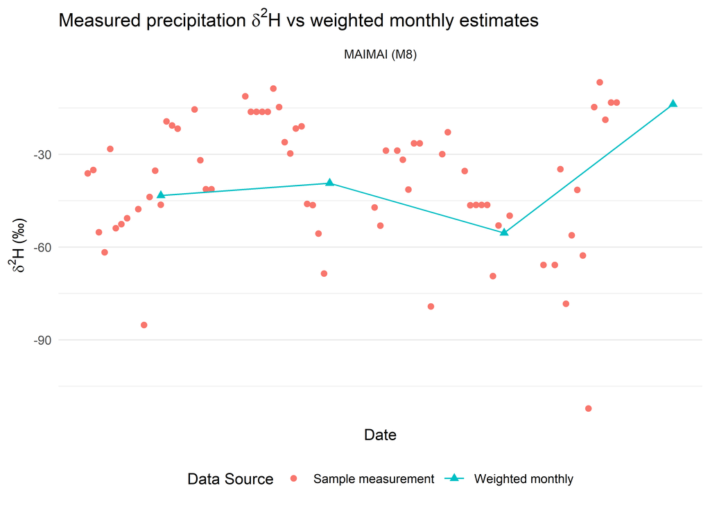

```r
library(dplyr)
library(ggplot2)
library(lubridate)

# Prepare monthly weighted d2H for plotting
monthly_weighted_d2H_plot <- monthly_weighted %>%
  mutate(Date = as.Date(paste(year, month, "15", sep = "-"))) %>%
  dplyr::select(Site_Name, Date, d2H = weighted_d2H) %>%
  mutate(Source = "Weighted monthly")

# Prepare sample measurements for d2H
precip_iso_d2H_plot <- daily_data %>%
  dplyr::select(Site_Name, Date = Collection_Date, d2H) %>%
  mutate(Source = "Sample measurement")

# Combine and clean
combined_plot_d2H <- bind_rows(monthly_weighted_d2H_plot, precip_iso_d2H_plot) %>%
  filter(!is.na(Date) & !is.na(d2H))

# Plot using facet_wrap
ggplot(combined_plot_d2H, aes(x = Date, y = d2H, color = Source, shape = Source)) +
  geom_point(size = 2) +
  geom_line(data = filter(combined_plot_d2H, Source == "Weighted monthly")) +
  facet_wrap(~ Site_Name, scales = "free_x") +
  scale_x_date(date_breaks = "1 year", date_labels = "%Y") +
  labs(
    title = expression("Measured precipitation " * delta^{2}*H * " vs weighted monthly estimates"),
    x = "Date",
    y = expression(delta^{2}*H~"(\u2030)"),
    color = "Data Source",
    shape = "Data Source"
  ) +
  theme_minimal() +
  theme(
    legend.position = "bottom",
    axis.text.x = element_text(angle = 45, hjust = 1)
  )
```

# 4 Import complete database

```r
 library(readxl)
Lookup_full_database <- read.csv("Full_lookup.csv")
# View(Lookup_full_database)

 Full_database <- read.csv("Full_dailyplus.csv")
# View(Full_database)
```

# 5 Database and lookup table cleaning

### 5.0.1 Check which Site_Name values in Full_database don’t match any in the lookup table

```r
# Get unmatched site names from Full_database
bad_sites_in_data <- setdiff(
  unique(Full_database$Site_Name),
  unique(Lookup_full_database$Site_Name)
)

# View them
bad_sites_in_data
```

```
character(0)
```

Check which Site_Name values in the lookup table don’t appear in Full_database

```r
# Get unmatched site names from Lookup table
unused_lookup_sites <- setdiff(
  unique(Lookup_full_database$Site_Name),
  unique(Full_database$Site_Name)
)

Lookup_full_database %>%
  filter(Site_Name %in% unused_lookup_sites) %>%
  select(Site_Name, Project) %>%
  distinct()
```

```
                                                         Site_Name
1                                                    GNIP  KAITOKE
2                                                GNIP CHRISTCHURCH
3                                Robert Creek above Firewood Creek
4                              1358 Winton - Dipton Highway (Snow)
5                         212 Bowmont Street - Invercargill (Snow)
6                           400 Venlaw Road - Venlaw Forest (Snow)
7                                   48 Watson Road - Dipton (Snow)
8                            49 South Hillend - Dipton Road (Snow)
9                                     500 Castle Downs Road (Snow)
10                              690 Cross Road - Pebblyhill (Snow)
11                          715 South Hillend - Dipton Road (Snow)
12         Bridge Railing at Bog Burn d/s Hundred Line Road (snow)
13                             Centre Bush at Ashton Street (Snow)
14                      Dunsdale Stream at Dunsdale Reserve (Snow)
```

[output cut: 183 more lines]

The sites with no data are either duplicates (Christchurch and Kaitoke GNIP data are in the Taylor 1990 dataset), snow sites where we can’t work out the date the snow fell, and one from Tim Kerr’s postdoc that didn’t have appropriate data. We can delete all these from the lookup table.

### 5.0.2 Clean out unneeded site lookup rows

```r
Lookup_filtered <- Lookup_full_database %>%
  filter(!(Site_Name %in% unused_lookup_sites))
```

### 5.0.3 Add in missing NZTM and NZMG to lookup table

```r
library(sf)
lookup_sf <- st_as_sf(Lookup_filtered, coords = c("long", "lat"), crs = 4326)
# Transform to NZTM
lookup_nztm <- st_transform(lookup_sf, crs = 2193)

# Extract NZTM coordinates
coords_nztm <- st_coordinates(lookup_nztm)

# Add to original dataframe
Lookup_filtered$NZTME <- coords_nztm[,1]  # Easting
Lookup_filtered$NZTMN <- coords_nztm[,2]  # Northing

# Transform to NZMG (legacy)
lookup_nzmg <- st_transform(lookup_sf, crs = 27200)

# Extract and add NZMG coords
coords_nzmg <- st_coordinates(lookup_nzmg)
Lookup_filtered$NZMGE <- coords_nzmg[,1]
Lookup_filtered$NZMGN <- coords_nzmg[,2]
```

### 5.0.4 Make reasonable project names for mapping

```r
project_name_map <- c(
  "CDRP" = "CDRP",
  "None" = "TUD",
  "GNIP/M/NZ/01" = "GNIP",
  "Forest Flows" = "Forest Flows",
  "Mt TeAroha " = "Mt Te Aroha",
  "Waihi Estuary Focus Catchment Investigation" = "Waihi Estuary",
  "Land Use Intensi?cation: Sustainable Management of Water Quantity and Quality Programme (NIWA)" = "LUWQ NIWA",
  "Rotorua Lakes FaCTS" = "Rotorua FaCTS",
  "NZWaM" = "NZWaM",
  "Taylor 1990" = "DSIR",
  "Tritium Input Function" = "GNS Tritium Input Function",
  "Phase1_early M8 catchment-scale research and observations (1974\x961988)" = "Maimai M8",
  "Hill AP transect" = "Hill AP transect",
  "Tim Kerr postdoc" = "Kerr Postdoc",
  "Hill AP transect / Jacks Thesis" = "Hill AP transect",
  "Waterscape" = "Waterscape",
  "Jack thesis + Zane thesis" = "UC Postgrad",
  "AOSnow" = "Hill AOSnow",
  "Jack thesis" = "UC Postgrad",
  "Ashley Dene" = "Ashley Dene",
  "Hill Haast transect" = "Hill Haast transect",
  "Environment Southland" = "Environment Southland",
  "B3" = "B3",
  "Nehemy/Simmons tree water sources " = "Trent University"
)

# Apply the updated project name map
Lookup_filtered$Project_clean <- dplyr::recode(Lookup_filtered$Project, !!!project_name_map)
```

## 5.1 Site map showing sites split by project

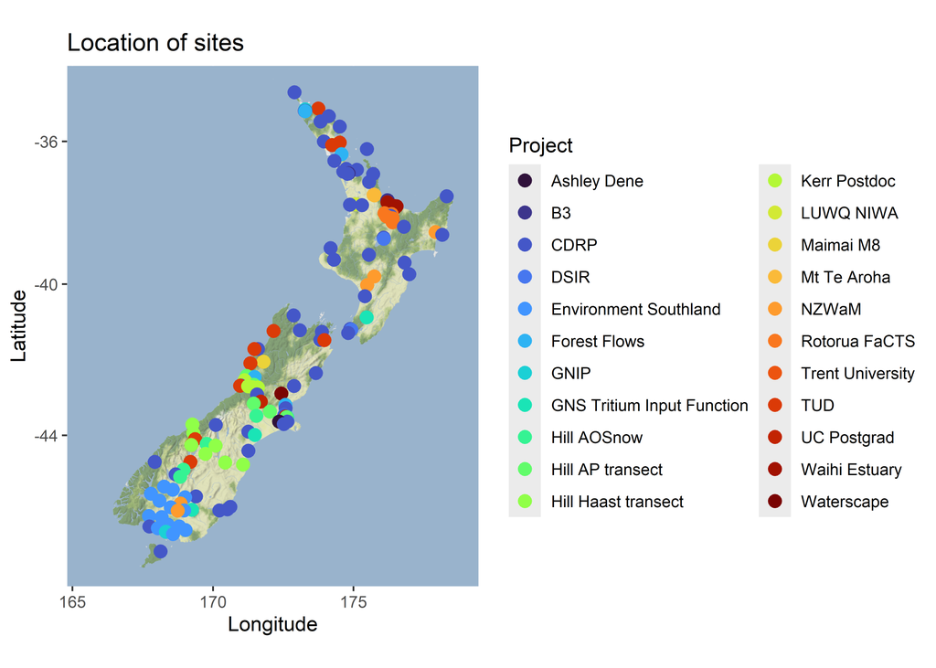

```r
source('scripts/auxiliary.code_BD.R')
ggmap::register_stadiamaps(key = "3ee03876-1ca3-4727-9391-cb8475022ba2")

Lookup_filtered$Color <- Lookup_filtered$Project_clean

# Add a numbered site label from north to south
Lookup_filtered <- Lookup_filtered %>%
  arrange(desc(lat)) %>%
  mutate(Site_Label = row_number())

site_map <- iso_plot_site_locations_BD(
  the.data = Lookup_filtered,
  site.column.name = "Site_Label",
  lat.column.name = "lat",
  lon.column.name = "long",
  color.column.name = "Color",
  island = "NZ"
)

print(site_map)
```

```r
ggsave("outputs/site_map.pdf", site_map, width = 10, height = 8)
```

# 6 Load VCSN climate data for isotope data date ranges for all sites

### 6.0.1 Join long/lat to main dataset

We’ll add lat and long columns to Full_database using the Site_Name as the join key:

```r
Full_database <- Full_database %>%
  left_join(
    Lookup_filtered %>% select(Site_Name, long, lat),
    by = "Site_Name"
  )
```

### 6.0.2 Add VCSN Agent (nearest climate grid point) to each site

This attaches the nearest VCSN grid point to each site in the Lookup_filtered table:

```r
lookup_with_vcsn <- Lookup_filtered %>%
  rename(lon = long) %>%
  vcsn_append_nearest_vcsn(VCSN.directory)
```

### 6.0.3 Check date formats on start and collection dates

```r
# Step 1: Check current column classes
str(Full_database[, c("Start_Date", "Collection_Date")])
```

```
'data.frame':   5295 obs. of  2 variables:
 $ Start_Date     : chr  "7/08/2014" "8/08/2014" "11/08/2014" "12/08/2014" ...
 $ Collection_Date: chr  "8/08/2014" "11/08/2014" "12/08/2014" "13/08/2014" ...
```

Convert date strings to Date format

```r
library(dplyr)

Full_database <- Full_database %>%
  mutate(
    Start_Date = as.Date(Start_Date, format = "%d/%m/%Y"),
    Collection_Date = as.Date(Collection_Date, format = "%d/%m/%Y")
  )
```

```r
Full_database %>%
  filter(is.na(Start_Date) | is.na(Collection_Date)) %>%
  select(Site_Name, SampleID, Start_Date, Collection_Date)
```

```
      Site_Name            SampleID Start_Date Collection_Date
1  Arthurs Pass Hill W-E APass - 74       <NA>            <NA>
2  Arthurs Pass Hill W-E APass - 76       <NA>            <NA>
3         Okaro   OKR_IOSOOH_041218       <NA>            <NA>
4   Camp Stream              CSAS 1       <NA>            <NA>
5   Camp Stream              CSAS 2       <NA>            <NA>
6   Camp Stream              CSAS 3       <NA>            <NA>
7   Camp Stream              CSAS 4       <NA>            <NA>
8   Camp Stream              CSAS 5       <NA>            <NA>
9   Camp Stream              CSAS 6       <NA>            <NA>
10  Camp Stream              CSAS 7       <NA>            <NA>
11  Camp Stream              CSAS 8       <NA>            <NA>
12  Camp Stream              CSFS 1       <NA>            <NA>
13  Camp Stream              CSFS 2       <NA>            <NA>
14  Camp Stream              CSFS 3       <NA>            <NA>
```

[output cut: 17 more lines]

```r
Full_database <- Full_database %>%
  filter(!is.na(Start_Date) & !is.na(Collection_Date))
```

Check for American interference in date formats!!

This step checks for each site, whether the Start_Date or Collection_Date ever go backward in time, which would strongly suggest a date parsing issue.

```r
library(dplyr)
library(lubridate)

# Ensure dates are only converted from character to Date
Full_database <- Full_database %>%
  mutate(
    Start_Date = if (is.character(Start_Date)) dmy(Start_Date) else Start_Date,
    Collection_Date = if (is.character(Collection_Date)) dmy(Collection_Date) else Collection_Date
  )

# Find sites with non-sequential Collection_Date
bad_collection <- Full_database %>%
  group_by(Site_Name) %>%
  arrange(Site_Name, Collection_Date) %>%
  mutate(date_diff = Collection_Date - lag(Collection_Date)) %>%
  filter(!is.na(date_diff) & date_diff < 0) %>%
  ungroup()

# Find sites with non-sequential Start_Date
bad_start <- Full_database %>%
  group_by(Site_Name) %>%
  arrange(Site_Name, Start_Date) %>%
  mutate(date_diff = Start_Date - lag(Start_Date)) %>%
  filter(!is.na(date_diff) & date_diff < 0) %>%
  ungroup()

# Print a summary
cat("🚨 Sites with Collection_Date going backward:\n")
```

```
🚨 Sites with Collection_Date going backward:
```

```r
print(unique(bad_collection$Site_Name))
```

```
character(0)
```

```r
cat("\n🚨 Sites with Start_Date going backward:\n")
```

```
🚨 Sites with Start_Date going backward:
```

```r
print(unique(bad_start$Site_Name))
```

```
character(0)
```

## 6.1 The actual VCSN climate data extraction

### 6.1.1 First test for a single site

```r
# Select the first unique site name
this_site <- unique(lookup_with_vcsn$Site_Name)[1]

# Print the site name explicitly
cat("\n=== Starting site:", this_site, "===\n")
```

```
=== Starting site: FREW 6 ===
```

```r
# Subset lookup and isotope data for this site
this_lookup <- lookup_with_vcsn %>% filter(Site_Name == this_site)
this_isotope <- Full_database %>% filter(Site_Name == this_site)

# Sanity check
cat("  → Isotope rows:", nrow(this_isotope), "\n")
```

```
  → Isotope rows: 30
```

```r
cat("  → Start_Date NA count:", sum(is.na(this_isotope$Start_Date)), "/", nrow(this_isotope), "\n")
```

```
  → Start_Date NA count: 0 / 30
```

```r
if (nrow(this_isotope) == 0 || all(is.na(this_isotope$Start_Date))) {
  cat("⚠️  No data or missing Start_Date — skipping site.\n")
} else {

  # Determine date range of measurements
  date_range <- this_isotope %>%
    summarise(
      min_date = min(Start_Date, na.rm = TRUE),
      max_date = max(Collection_Date, na.rm = TRUE)
    )

  years_needed <- seq(year(date_range$min_date), year(date_range$max_date))
  cat("  → Years needed:", paste(years_needed, collapse = ", "), "\n")

  # Pull VCSN data
  this_climate <- vcsn_append_climate_information(this_lookup, VCSN.directory, years_needed)

  # Filter to the actual collection period
  this_climate <- this_climate %>%
    filter(Date >= date_range$min_date, Date <= date_range$max_date)

  # Show head of result
  cat("\n✅ Done with site:", this_site, "\n\n")
  print(head(this_climate))
}
```

```
  → Years needed: 2007, 2008, 2009, 2010
```

```
✅ Done with site: FREW 6

  Site_Name               Group Project     lon     lat   NZMGE   NZMGN   NZTME
1    FREW 6 University of Otago    CDRP 172.893 -34.572 2501191 6736634 1590186
2    FREW 6 University of Otago    CDRP 172.893 -34.572 2501191 6736634 1590186
3    FREW 6 University of Otago    CDRP 172.893 -34.572 2501191 6736634 1590186
4    FREW 6 University of Otago    CDRP 172.893 -34.572 2501191 6736634 1590186
5    FREW 6 University of Otago    CDRP 172.893 -34.572 2501191 6736634 1590186
6    FREW 6 University of Otago    CDRP 172.893 -34.572 2501191 6736634 1590186
    NZTMN Elevation_masl Frequency time.series.greater.than.2.yrs. Published
1 6174414             55   Monthly                                       Yes
2 6174414             55   Monthly                                       Yes
3 6174414             55   Monthly                                       Yes
4 6174414             55   Monthly                                       Yes
5 6174414             55   Monthly                                       Yes
```

[output cut: 29 more lines]

### 6.1.2 Full extraction

```r
# Create output directory if it doesn't exist
output_dir <- "output"
if (!dir.exists(output_dir)) dir.create(output_dir)

# Loop over each site in the lookup table
for (this_site in unique(lookup_with_vcsn$Site_Name)) {

  # Generate expected filename
  outfile <- file.path(output_dir, paste0("vcsn_data_", gsub("[^A-Za-z0-9_]", "", gsub(" ", "_", this_site)), ".rds"))

  # Skip if file already exists
  if (file.exists(outfile)) {
    cat("\n⏭️ Skipping site (already processed):", this_site, "\n")
    next
  }

  start_time <- Sys.time()
  cat("\n=== Starting site:", this_site, "===\n")

  # Subset lookup and isotope data for this site
  this_lookup <- lookup_with_vcsn %>% filter(Site_Name == this_site)
  this_isotope <- Full_database %>% filter(Site_Name == this_site)

  cat("  → Isotope rows:", nrow(this_isotope), "\n")
  cat("  → Start_Date NA count:", sum(is.na(this_isotope$Start_Date)), "/", nrow(this_isotope), "\n")

  if (nrow(this_isotope) == 0 || all(is.na(this_isotope$Start_Date))) {
    cat("⚠️  No data or missing Start_Date — skipping site.\n")
    next
  }

  # Determine date range of measurements
  date_range <- this_isotope %>%
    summarise(
      min_date = min(Start_Date, na.rm = TRUE),
      max_date = max(Collection_Date, na.rm = TRUE)
    )

  years_needed <- seq(year(date_range$min_date), year(date_range$max_date))
  cat("  → Years needed:", paste(years_needed, collapse = ", "), "\n")

  # Pull VCSN data
  this_climate <- vcsn_append_climate_information(this_lookup, VCSN.directory, years_needed)

  # Filter to the actual collection period
  this_climate <- this_climate %>%
    filter(Date >= date_range$min_date, Date <= date_range$max_date)

  # Save the data
  saveRDS(this_climate, file = outfile)

  duration <- round(difftime(Sys.time(), start_time, units = "secs"), 2)
  cat("✅ Done with site:", this_site, "| Duration:", duration, "seconds\n")
}
```

```
⏭️ Skipping site (already processed): FREW 6

⏭️ Skipping site (already processed): Whangaroa Rain

⏭️ Skipping site (already processed): GNIP KAITAIA

⏭️ Skipping site (already processed): B3. Kaitaia

⏭️ Skipping site (already processed): FREW 1

⏭️ Skipping site (already processed): Te Hiku

⏭️ Skipping site (already processed): FREW 5

⏭️ Skipping site (already processed): FREW 4

⏭️ Skipping site (already processed): FREW 3

⏭️ Skipping site (already processed): FREW 2

⏭️ Skipping site (already processed): Waipu Cove Rain

⏭️ Skipping site (already processed): Paparoa Rain

⏭️ Skipping site (already processed): FREW 16

⏭️ Skipping site (already processed): Mahurangi

⏭️ Skipping site (already processed): FREW 13

⏭️ Skipping site (already processed): FREW 7

⏭️ Skipping site (already processed): FREW 10

⏭️ Skipping site (already processed): FREW 8

⏭️ Skipping site (already processed): FREW 11

⏭️ Skipping site (already processed): B3.Auckland

```

[output cut: 248 more lines]

```
⏭️ Skipping site (already processed): FREW 49

⏭️ Skipping site (already processed): Edendale at Coal Pit Road

⏭️ Skipping site (already processed): Lower Aparima Aquifer at Riverton

⏭️ Skipping site (already processed): Mokoreta at Mt Alexander

⏭️ Skipping site (already processed): Waihopai River at Waihopai Dam

⏭️ Skipping site (already processed): GNIP INVERCARGILL

⏭️ Skipping site (already processed): Waituna at Lawson Road

⏭️ Skipping site (already processed): FREW 50
```

# 7 Stack all the data together

```r
library(purrr)
library(dplyr)

# Combine all dataframes in the list into one, adding site name as a column
climate_data_all <- map2_dfr(
  .x = climate_data_all_sites,
  .y = names(climate_data_all_sites),
  .f = ~ mutate(.x, Site_Label_From_ListName = .y)
)
# Tidy up

climate_data_all <- climate_data_all %>%
  select(-`VCSN.lat...24`, -`VCSN.lon...25`) %>%  # remove duplicate columns
  rename(
    VCSN.lat = `VCSN.lat...22`,
    VCSN.lon = `VCSN.lon...23`
  )

head(climate_data_all)
```

```
       Site_Name Group             Project      lon      lat   NZMGE   NZMGN
1 Ahuriri Valley  NIWA Hill Haast transect 169.7264 -44.4725 2249596 5632104
2 Ahuriri Valley  NIWA Hill Haast transect 169.7264 -44.4725 2249596 5632104
3 Ahuriri Valley  NIWA Hill Haast transect 169.7264 -44.4725 2249596 5632104
4 Ahuriri Valley  NIWA Hill Haast transect 169.7264 -44.4725 2249596 5632104
5 Ahuriri Valley  NIWA Hill Haast transect 169.7264 -44.4725 2249596 5632104
6 Ahuriri Valley  NIWA Hill Haast transect 169.7264 -44.4725 2249596 5632104
    NZTME   NZTMN Elevation_masl Frequency time.series.greater.than.2.yrs.
1 1339631 5070432            610   Monthly
2 1339631 5070432            610   Monthly
3 1339631 5070432            610   Monthly
4 1339631 5070432            610   Monthly
5 1339631 5070432            610   Monthly
6 1339631 5070432            610   Monthly
  Published Reference Contact_Name      Contact_Email
```

[output cut: 34 more lines]

# 8 Revised function to assign isotope values to each rainfall day within a collection period

```r
# Make sure dates are Date class
Full_database <- Full_database %>%
  mutate(
    Start_Date = as.Date(Start_Date),
    Collection_Date = as.Date(Collection_Date)
  )

# Function stays the same — no changes needed
assign_isotopes_to_days <- function(site_df, iso_df, site_name) {
  site_climate <- site_df %>% filter(Site_Name == site_name)
  site_isotopes <- iso_df %>% filter(Site_Name == site_name)

  assigned_values <- pmap(
    list(site_isotopes$Start_Date, site_isotopes$Collection_Date, site_isotopes$d2H, site_isotopes$d18O),
    function(start_date, end_date, d2h_val, d18o_val) {
      if (is.na(start_date) | is.na(end_date) | start_date >= end_date) return(NULL)

      tibble(
        Date = seq.Date(start_date, end_date - 1, by = "day"),
        Site_Name = site_name,
        d2H = d2h_val,
        d18O = d18o_val
      )
    }
  )

  assigned_df <- bind_rows(assigned_values)

  left_join(site_climate, assigned_df, by = c("Date", "Site_Name"))
}

# Apply to the first site
first_site <- unique(Full_database$Site_Name)[1]

assigned_data <- assign_isotopes_to_days(climate_data_all, Full_database, first_site)
```

Clean out one problematic site

```r
# Remove the site from both datasets
Full_database <- Full_database %>% filter(Site_Name != "Pokopoko at Allport Rd")
climate_data_all <- climate_data_all %>% filter(Site_Name != "Pokopoko at Allport Rd")
```

# 9 Full loop to assign isotope values to daily precipitation amounts

```r
# Make sure date columns are Date class
Full_database <- Full_database %>%
  mutate(
    Start_Date = as.Date(Start_Date),
    Collection_Date = as.Date(Collection_Date)
  )

assign_isotopes_to_days <- function(site_df, iso_df, site_name) {
  site_climate <- site_df %>% filter(Site_Name == site_name)
  site_isotopes <- iso_df %>% filter(Site_Name == site_name)

  assigned_values <- pmap(
    list(site_isotopes$Start_Date, site_isotopes$Collection_Date, site_isotopes$d2H, site_isotopes$d18O),
    function(start_date, end_date, d2h_val, d18o_val) {
      if (is.na(start_date) | is.na(end_date)) return(NULL)

      date_seq <- if (start_date < end_date) {
        seq.Date(start_date, end_date - 1, by = "day")  # normal case
      } else if (start_date == end_date) {
        start_date  # single-day case
      } else {
        return(NULL)  # invalid range
      }

      tibble(
        Date = date_seq,
        Site_Name = site_name,
        d2H = d2h_val,
        d18O = d18o_val
      )
    }
  )

  assigned_df <- bind_rows(assigned_values)

  if (nrow(assigned_df) == 0) {
    message("⚠️ No valid date range for site: ", site_name)
    return(site_climate %>% mutate(d2H = NA_real_, d18O = NA_real_))
  } else {
    return(left_join(site_climate, assigned_df, by = c("Date", "Site_Name")))
  }
}


# Loop over all unique sites and bind results
all_sites <- unique(Full_database$Site_Name)

assigned_all_sites <- map_dfr(all_sites, function(site) {
  cat("Processing site:", site, "\n")
  assign_isotopes_to_days(climate_data_all, Full_database, site)
})
```

```
Processing site: Melrose Farm
Processing site: Greymouth
Processing site: Ashley Dene
Processing site: Christchurch
Processing site: Sheffield
Processing site: Lake Coleridge
Processing site: Arthurs Pass
Processing site: Inchbonnie
Processing site: Ashley Forest
Processing site: Mahurangi
Processing site: Mawhera Forest
Processing site: Te Hiku
Processing site: Balfour at Glenure St Patricks Road
Processing site: Central Plains Aquifer at Heddon Bush
Processing site: Edendale at Coal Pit Road
Processing site: Fairlight at Cainard Station
Processing site: Hamilton Burn at Mt Hamilton Road
Processing site: Lower Aparima Aquifer at Riverton
Processing site: Makarewa Aquifer at Mckinnon Road
Processing site: McKellars Flat at Gorge Burn
Processing site: Mokoreta at Mt Alexander
Processing site: Riversdale Aquifer at Liverpool Street
Processing site: Waiau River at Clifden
Processing site: Waihopai River at Waihopai Dam
Processing site: Waikaia River at Piano Flat
Processing site: Waituna at Lawson Road
Processing site: Wendon Valley at Waikaka
Processing site: Whitestone Aquifer at Lynwood
Processing site: FREW 1
Processing site: FREW 10
Processing site: FREW 11
Processing site: FREW 13
Processing site: FREW 14
Processing site: FREW 15
Processing site: FREW 16
Processing site: FREW 17
Processing site: FREW 18
Processing site: FREW 19
Processing site: FREW 2
Processing site: FREW 20
```

[output cut: 95 more lines]

```
Processing site: Pokopoko at Old Coach Rd
Processing site: Pongakawa Tributary at Old Coach Road
Processing site: Wharere at 975 Maniatutu Rd
Processing site: MAIMAI (M8)
Processing site: Kumara Beach rain
Processing site: Arthurs Pass rain
Processing site: Taipo at bridge rain
Processing site: Harris Creek rain
Processing site: Taramakau at SH73 rain
Processing site: Canal rain
Processing site: B3. Kaitaia
Processing site: B3.Auckland
Processing site: B3.Mt Manganui
Processing site: B3.Christchurch
Processing site: M8_Maimai
```

# 10 Generate monthly rainfall weighted values

```r
monthly_weighted <- assigned_all_sites %>%
  mutate(
    Rain_bc = as.numeric(Rain_bc),
    d2H = as.numeric(d2H),
    d18O = as.numeric(d18O),
    year = year(Date),
    month = month(Date),
    year_month = floor_date(Date, "month")
  ) %>%
  # Only retain rows where isotope values are not NA
  filter(!is.na(d2H) | !is.na(d18O)) %>%
  group_by(Site_Name, year, month, year_month) %>%
  summarise(
    total_rainfall = sum(Rain_bc, na.rm = TRUE),
    weighted_d2H = if (all(is.na(d2H)) || sum(Rain_bc, na.rm = TRUE) == 0) NA else
      sum(Rain_bc * d2H, na.rm = TRUE) / sum(Rain_bc, na.rm = TRUE),
    weighted_d18O = if (all(is.na(d18O)) || sum(Rain_bc, na.rm = TRUE) == 0) NA else
      sum(Rain_bc * d18O, na.rm = TRUE) / sum(Rain_bc, na.rm = TRUE),

    # ✅ Count ALL distinct days with a record (regardless of rain)
    days_present = n_distinct(Date),

    expected_days = days_in_month(first(Date)),
    missing_days = expected_days - days_present,
    incomplete_month = ifelse(missing_days > 0, "YES", "NO"),
    sparse_month = days_present < 20,

    .groups = "drop"
  )
```

# 11 Plotting back against measured values

```r
library(dplyr)
library(ggplot2)
library(lubridate)

# 0. Remove sparse monthly values
monthly_weighted_filtered <- monthly_weighted %>%
  filter(!sparse_month) %>%
  group_by(Site_Name) %>%
  filter(n() > 0) %>%  # Only keep sites with valid data
  ungroup()

# ==== d2H ====

# 1. Monthly weighted d2H for plotting: set date to 1st of next month
monthly_weighted_d2H_plot <- monthly_weighted_filtered %>%
  mutate(Date = make_date(year, month, 1) %>% ceiling_date(unit = "month")) %>%
  select(Site_Name, Date, d2H = weighted_d2H) %>%
  mutate(Source = "Weighted monthly")

# 2. Sample d2H measurements
precip_iso_d2H_plot <- Full_database %>%
  mutate(Collection_Date = as.Date(Collection_Date)) %>%
  select(Site_Name, Date = Collection_Date, d2H) %>%
  mutate(d2H = as.numeric(d2H), Source = "Sample measurement")

# 3. Combine
valid_sites_d2H <- unique(monthly_weighted_d2H_plot$Site_Name)
combined_plot_d2H <- bind_rows(
  monthly_weighted_d2H_plot,
  precip_iso_d2H_plot %>% filter(Site_Name %in% valid_sites_d2H)
) %>%
  filter(!is.na(Date) & !is.na(d2H))

# 4. Save d2H plots
dir.create("plots", showWarnings = FALSE)
pdf("plots/d2H_weighted_vs_measured_by_site.pdf", width = 10, height = 6)

for (site in unique(combined_plot_d2H$Site_Name)) {
  this_data <- combined_plot_d2H %>% filter(Site_Name == site)

  p <- ggplot(this_data, aes(x = Date, y = d2H, color = Source, shape = Source)) +
    geom_point(size = 2, alpha = 0.8) +
    geom_line(data = filter(this_data, Source == "Weighted monthly"), aes(group = 1), linewidth = 1) +
    scale_x_date(date_breaks = "1 year", date_labels = "%Y") +
    labs(
      title = paste0("Measured vs Weighted δ²H - ", site),
      x = "Date",
      y = expression(delta^{2}*H~"(\u2030)"),
      color = "Data Source",
      shape = "Data Source"
    ) +
    theme_minimal() +
    theme(
      legend.position = "bottom",
      axis.text.x = element_text(angle = 45, hjust = 1),
      strip.text = element_text(size = 10)
    )

  print(p)
}
dev.off()
```

```r
# ==== d18O ====

# 5. Monthly weighted d18O
monthly_weighted_d18O_plot <- monthly_weighted_filtered %>%
  mutate(Date = make_date(year, month, 1) %>% ceiling_date(unit = "month")) %>%
  select(Site_Name, Date, d18O = weighted_d18O) %>%
  mutate(Source = "Weighted monthly")

# 6. Sample d18O measurements
precip_iso_d18O_plot <- Full_database %>%
  mutate(Collection_Date = as.Date(Collection_Date)) %>%
  select(Site_Name, Date = Collection_Date, d18O) %>%
  mutate(d18O = as.numeric(d18O), Source = "Sample measurement")

# 7. Combine
valid_sites_d18O <- unique(monthly_weighted_d18O_plot$Site_Name)
combined_plot_d18O <- bind_rows(
  monthly_weighted_d18O_plot,
  precip_iso_d18O_plot %>% filter(Site_Name %in% valid_sites_d18O)
) %>%
  filter(!is.na(Date) & !is.na(d18O))

# 8. Save d18O plots
pdf("plots/d18O_weighted_vs_measured_by_site.pdf", width = 10, height = 6)

for (site in unique(combined_plot_d18O$Site_Name)) {
  this_data <- combined_plot_d18O %>% filter(Site_Name == site)

  p <- ggplot(this_data, aes(x = Date, y = d18O, color = Source, shape = Source)) +
    geom_point(size = 2, alpha = 0.8) +
    geom_line(data = filter(this_data, Source == "Weighted monthly"), aes(group = 1), linewidth = 1) +
    scale_x_date(date_breaks = "1 year", date_labels = "%Y") +
    labs(
      title = paste0("Measured vs Weighted δ¹⁸O - ", site),
      x = "Date",
      y = expression(delta^{18}*O~"(\u2030)"),
      color = "Data Source",
      shape = "Data Source"
    ) +
    theme_minimal() +
    theme(
      legend.position = "bottom",
      axis.text.x = element_text(angle = 45, hjust = 1),
      strip.text = element_text(size = 10)
    )

  print(p)
}
dev.off()
```

# 12 Database add ins

Now we create the two new logical columns in monthly_weighted_filtered dataframe — composite and exact_month — we can use Full_database to check for: 1. composite == TRUE if a month’s data is the result of multiple samples (i.e. multiple rows in Full_database) covering that month at a site. 2. exact_month == TRUE if the data covers the full calendar month exactly:

```
The earliest Start_Date in that month is the first day of the month, and

The latest Collection_Date is the last day of the month or the first day of the following month.
```

```r
library(dplyr)
library(lubridate)

# 1. Prepare Full_database with month info
full_with_months <- Full_database %>%
  mutate(
    Start_Date = as.Date(Start_Date),
    Collection_Date = as.Date(Collection_Date),
    year = year(Start_Date),
    month = month(Start_Date)
  )

# 2. Summarise to get composite and exact_month flags
monthly_flags <- full_with_months %>%
  group_by(Site_Name, year, month) %>%
  summarise(
    n_samples = n(),
    min_start = min(Start_Date, na.rm = TRUE),
    max_end = max(Collection_Date, na.rm = TRUE),
    .groups = "drop"
  ) %>%
  mutate(
    composite = n_samples > 1,
    month_start = as.Date(sprintf("%d-%02d-01", year, month)),
    month_end = ceiling_date(month_start, "month") - days(1),
    next_month_start = ceiling_date(month_start, "month"),

    exact_month = min_start == month_start &
      (max_end == month_end | max_end == next_month_start)
  ) %>%
  select(Site_Name, year, month, composite, exact_month)

# 3. Join flags back to your monthly_weighted_filtered dataframe
monthly_weighted_flagged <- monthly_weighted_filtered %>%
  left_join(monthly_flags, by = c("Site_Name", "year", "month")) %>%
  mutate(
    composite = case_when(
      is.na(composite) ~ FALSE,                           # default
      TRUE ~ composite                                     # use original composite flag if available
    ),
    exact_month = ifelse(is.na(exact_month), FALSE, exact_month),

    # second-tier: classify as composite if not exact_month but still complete
    composite = ifelse(!exact_month & incomplete_month == "NO", TRUE, composite)
  )

head(monthly_weighted_flagged)
```

```
# A tibble: 6 × 14
  Site_Name      year month year_month total_rainfall weighted_d2H weighted_d18O
  <chr>         <dbl> <dbl> <date>              <dbl>        <dbl>         <dbl>
1 Ahuriri Vall…  2021    10 2021-10-01           47          -53.3         -7.78
2 Ahuriri Vall…  2021    11 2021-11-01           85.1        -71          -10.0
3 Ahuriri Vall…  2021    12 2021-12-01           91.9        -59.3         -8.45
4 Ahuriri Vall…  2022     1 2022-01-01           19.1        -88.7        -11.7
5 Ahuriri Vall…  2022     2 2022-02-01          126.         -91.2        -12.0
6 Ahuriri Vall…  2022     3 2022-03-01           11.8        -78.4        -10.5
# ℹ 7 more variables: days_present <int>, expected_days <int>,
#   missing_days <int>, incomplete_month <chr>, sparse_month <lgl>,
#   composite <lgl>, exact_month <lgl>
```

Check this is working:

```r
#monthly_weighted_flagged %>%
#  filter(Site_Name %in% c("MAIMAI (M8)", "Kaitoke Rain"))

#monthly_weighted_flagged %>%
 # filter(Site_Name == "MAIMAI (M8)")

#assigned_all_sites %>%
#  filter(Site_Name == "MAIMAI (M8)")
```

### 12.0.1 Table of different data types in the final weighted dataset

```r
# Step 1: Join project information into the flagged monthly data
monthly_with_project <- monthly_weighted_flagged %>%
  left_join(Lookup_filtered %>% select(Site_Name, Project_clean), by = "Site_Name")

# Step 2: Summarise by project
summary_by_project <- monthly_with_project %>%
  group_by(Project_clean) %>%
  summarise(
    n_sites = n_distinct(Site_Name),
    complete_months = sum(incomplete_month == "NO", na.rm = TRUE),
    non_sparse_months = sum(sparse_month == FALSE, na.rm = TRUE),
    exact_months = sum(exact_month == TRUE, na.rm = TRUE),
    .groups = "drop"
  ) %>%
  arrange(desc(n_sites))  # Optional: sort by number of sites
summary_by_project
```

```
# A tibble: 20 × 5
   Project_clean          n_sites complete_months non_sparse_months exact_months
   <chr>                    <int>           <int>             <int>        <int>
 1 CDRP                        55            1463              1463         1463
 2 Environment Southland       16             248               264            0
 3 Hill Haast transect          7             190               196           12
 4 Rotorua FaCTS                7             178               195            0
 5 Hill AP transect             6             138               164            0
 6 NZWaM                        6              92               103            1
 7 Mt Te Aroha                  5              60                65           10
 8 B3                           4              93                97            0
 9 Forest Flows                 4             112               115            0
10 GNS Tritium Input Fun…       4             216               221            1
11 Hill AOSnow                  4              13                17            0
12 DSIR                         3               0               275          275
13 GNIP                         2             523               523          523
14 Ashley Dene                  1              20                22            0
15 LUWQ NIWA                    1               0                 7            0
16 Maimai M8                    1               3                 3            3
17 Trent University             1               6                 6            0
18 UC Postgrad                  1               8                 8            0
19 Waihi Estuary                1               2                 3            0
20 Waterscape                   1              18                19            1
```

# 13 Testing for the effects of rainfall weighting using gridded climate data

1. Calculate a ‘true rainfall weighting’ column for monthly_weighted_flagged

First we need to clear the ‘measured’ values out from the CDRP sites - these are actually VCSN data.

```r
Full_database <- Full_database %>%
  mutate(Precipitation_mm = as.numeric(Precipitation_mm)) %>%
  mutate(Precipitation_mm = if_else(Project == "CDRP", NA_real_, Precipitation_mm))
```

Then create a dataframe with quasi-daily precipitation isotope data and precipitaion amount data

```r
library(dplyr)

selected_sites <- c("B3. Kaitaia", "B3.Christchurch", "Ashley Dene"
                                     ,"MAIMAI (M8)", "Melrose Farm")

site_rain_data <- Full_database %>%
  filter(Site_Name %in% selected_sites)
```

Add in some precip. data for Ashley Dene, and two of the B3 sites

```r
deneprecip<-read.csv("precip/Ashley Dene precipitation.csv")
kaitaiaprecip<-read.csv("precip/kaitaia.csv")
niwachch<-read.csv("precip/niwachch.csv")

library(dplyr)
library(lubridate)

# Ensure Date columns are in Date format
site_rain_data <- site_rain_data %>%
  mutate(Start_Date = as.Date(Start_Date),
         Collection_Date = as.Date(Collection_Date))

deneprecip <- deneprecip %>%
  mutate(Date = as.Date(Date, format = "%d/%m/%Y"))

kataiaprecip <- kaitaiaprecip %>%
  mutate(Date = as.Date(Date, format = "%d/%m/%Y"))

niwachch <- niwachch %>%
  mutate(Date = as.Date(Date, format = "%d/%m/%Y"))

# --- Ashley Dene
ashley_dene_samples <- site_rain_data %>%
  filter(Project == "Ashley Dene") %>%
  rowwise() %>%
  mutate(precip_sum = sum(
    deneprecip$Precipitation_mm[
      deneprecip$Date >= Start_Date & deneprecip$Date < Collection_Date
    ],
    na.rm = TRUE
  )) %>%
  ungroup()

# --- B3. Kaitaia
kaitaia_samples <- site_rain_data %>%
  filter(Site_Name == "B3. Kaitaia") %>%
  rowwise() %>%
  mutate(precip_sum = sum(
    kataiaprecip$Rainfall.mm[
      kataiaprecip$Date >= Start_Date & kataiaprecip$Date < Collection_Date
    ],
    na.rm = TRUE
  )) %>%
  ungroup()

# --- B3.Christchurch
chch_samples <- site_rain_data %>%
  filter(Site_Name == "B3.Christchurch") %>%
  rowwise() %>%
  mutate(precip_sum = sum(
    niwachch$Rain.mm[
      niwachch$Date >= Start_Date & niwachch$Date < Collection_Date
    ],
    na.rm = TRUE
  )) %>%
  ungroup()

# Combine and update Precipitation_mm
updated_precip <- bind_rows(
  ashley_dene_samples %>% select(Site_Name, SampleID, precip_sum),
  kaitaia_samples %>% select(Site_Name, SampleID, precip_sum),
  chch_samples %>% select(Site_Name, SampleID, precip_sum)
)

site_rain_data <- site_rain_data %>%
  mutate(Precipitation_mm = as.numeric(Precipitation_mm)) %>%
  left_join(updated_precip, by = c("Site_Name", "SampleID")) %>%
  mutate(Precipitation_mm = if_else(!is.na(precip_sum), precip_sum, Precipitation_mm)) %>%
  select(-precip_sum)
```

Check for rows with missing precipitation data, and count total rows and which sites are covered

```r
# Count total missing values
site_rain_data %>%
  filter(is.na(as.numeric(Precipitation_mm))) %>%
  summarise(n_missing = n())
```

```
  n_missing
1         0
```

```r
# Count missing values by site
site_rain_data %>%
  filter(is.na(as.numeric(Precipitation_mm))) %>%
  count(Site_Name, sort = TRUE)
```

```
[1] Site_Name n
<0 rows> (or 0-length row.names)
```

```r
nrow(site_rain_data)
```

```
[1] 682
```

```r
unique(site_rain_data$Site_Name)
```

```
[1] "Melrose Farm"    "Ashley Dene"     "MAIMAI (M8)"     "B3. Kaitaia"
[5] "B3.Christchurch"
```

Now expand to a daily dataFrame

We’ll:

```
Convert each sample into a sequence of dates based on the collection period

Distribute rainfall equally across days in the period (excluding the final collection day)

Assign the same isotope value (d18O, d2H) to each day in the period

Then we'll combine all samples into one daily-level dataframe
```

```r
library(dplyr)
library(tidyr)
library(purrr)
library(lubridate)

# Ensure dates are properly formatted (you already have this from glimpse)
daily_expanded <- site_rain_data %>%
  # Calculate the number of days in each sampling period (excluding collection day)
  mutate(
    Start_Date = as.Date(Start_Date),
    Collection_Date = as.Date(Collection_Date),
    days = as.numeric(Collection_Date - Start_Date)
  ) %>%
  # Filter out any zero-day or malformed samples
  filter(days > 0 & !is.na(Precipitation_mm)) %>%
  # Expand each row into daily records
  rowwise() %>%
  mutate(
    date_seq = list(seq.Date(Start_Date, Collection_Date - 1, by = "day")),
    rain_per_day = Precipitation_mm / days
  ) %>%
  ungroup() %>%
  unnest(cols = c(date_seq)) %>%
  mutate(
    Precipitation_mm = rain_per_day,
    d18O = as.numeric(d18O),
    d2H = as.numeric(d2H)
  ) %>%
  select(Site_Name, Project, date = date_seq, Precipitation_mm, d18O, d2H)
```

Rainfall-Weighted Monthly Means (calendar months)

Now we’ll:

```
Extract year/month

Group by site and calendar month

Calculate rainfall-weighted means for d18O and d2H
```

```r
rainfall_weighted_monthly <- daily_expanded %>%
  mutate(year_month = floor_date(date, unit = "month")) %>%
  group_by(Site_Name, Project, year_month) %>%
  summarise(
    total_rain = sum(Precipitation_mm, na.rm = TRUE),

    weighted_d18O = if (all(is.na(d18O) | Precipitation_mm == 0)) NA_real_ else
      sum(d18O * Precipitation_mm, na.rm = TRUE) / sum(Precipitation_mm[!is.na(d18O)], na.rm = TRUE),

    weighted_d2H = if (all(is.na(d2H) | Precipitation_mm == 0)) NA_real_ else
      sum(d2H * Precipitation_mm, na.rm = TRUE) / sum(Precipitation_mm[!is.na(d2H)], na.rm = TRUE),

    .groups = "drop"
  ) %>%
  # If total rainfall is zero, set isotope values to NA
  mutate(
    weighted_d18O = ifelse(total_rain == 0, NA_real_, weighted_d18O),
    weighted_d2H  = ifelse(total_rain == 0, NA_real_, weighted_d2H)
  )
```

```r
library(dplyr)
library(lubridate)

# Step 1: Rename VCSN-derived columns
monthly_flagged_renamed <- monthly_weighted_flagged %>%
  rename(
    VCSN_total_rainfall = total_rainfall,
    VCSN_weighted_d2H = weighted_d2H,
    VCSN_weighted_d18O = weighted_d18O
  )


# Perform a left join to bring the adjusted rainfall and isotope values into the VCSN dataframe
monthly_combined <- monthly_flagged_renamed %>%
  left_join(
    rainfall_weighted_monthly %>%
      select(Site_Name, year_month,
             Adjusted_total_rain = total_rain,
             Adjusted_weighted_d18O = weighted_d18O,
             Adjusted_weighted_d2H = weighted_d2H),
    by = c("Site_Name", "year_month")
  )
```

Now cut the dataframe down for plotting

```r
filtered_df <- monthly_combined %>%
  filter(!is.na(Adjusted_total_rain))
```

### 13.0.1 Check to see why the plots below are missing a couple of sites in the html file…

```r
unique(filtered_df$Site_Name)
```

```
[1] "Ashley Dene"     "B3. Kaitaia"     "B3.Christchurch" "MAIMAI (M8)"
[5] "Melrose Farm"
```

## 13.1 Comparison plots and RMSE calculations

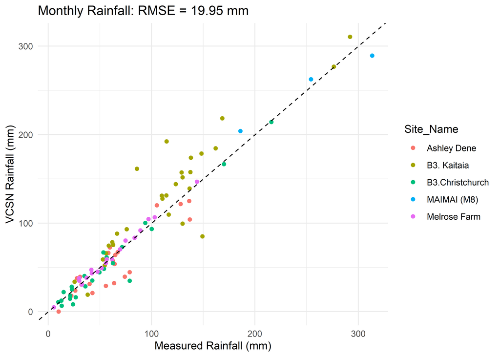

```r
library(ggplot2)
library(dplyr)

# Calculate RMSE values for each variable
rmse_rain <- sqrt(mean((filtered_df$VCSN_total_rainfall - filtered_df$Adjusted_total_rain)^2, na.rm = TRUE))
rmse_d18O <- sqrt(mean((filtered_df$VCSN_weighted_d18O - filtered_df$Adjusted_weighted_d18O)^2, na.rm = TRUE))
rmse_d2H  <- sqrt(mean((filtered_df$VCSN_weighted_d2H - filtered_df$Adjusted_weighted_d2H)^2, na.rm = TRUE))

# Plot for Rainfall
rain_plot <- ggplot(filtered_df, aes(x = Adjusted_total_rain, y = VCSN_total_rainfall, color = Site_Name)) +
  geom_point() +
  geom_abline(slope = 1, intercept = 0, linetype = "dashed") +
  labs(title = paste0("Monthly Rainfall: RMSE = ", round(rmse_rain, 2), " mm"),
       x = "Measured Rainfall (mm)",
       y = "VCSN Rainfall (mm)") +
  theme_minimal()

# Plot for d18O
d18O_plot <- ggplot(filtered_df, aes(x = Adjusted_weighted_d18O, y = VCSN_weighted_d18O, color = Site_Name)) +
  geom_point() +
  geom_abline(slope = 1, intercept = 0, linetype = "dashed") +
  labs(title = paste0("Monthly d18O: RMSE = ", round(rmse_d18O, 2), " ‰"),
       x = "Measured d18O (‰)",
       y = "VCSN d18O (‰)") +
  theme_minimal()

# Plot for d2H
d2H_plot <- ggplot(filtered_df, aes(x = Adjusted_weighted_d2H, y = VCSN_weighted_d2H, color = Site_Name)) +
  geom_point() +
  geom_abline(slope = 1, intercept = 0, linetype = "dashed") +
  labs(title = paste0("Monthly d2H: RMSE = ", round(rmse_d2H, 2), " ‰"),
       x = "Measured d2H (‰)",
       y = "VCSN d2H (‰)") +
  theme_minimal()

# Print plots
print(rain_plot)
```

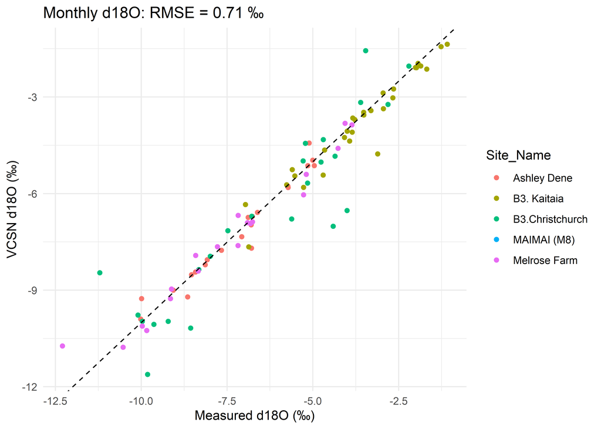

```r
print(d18O_plot)
```

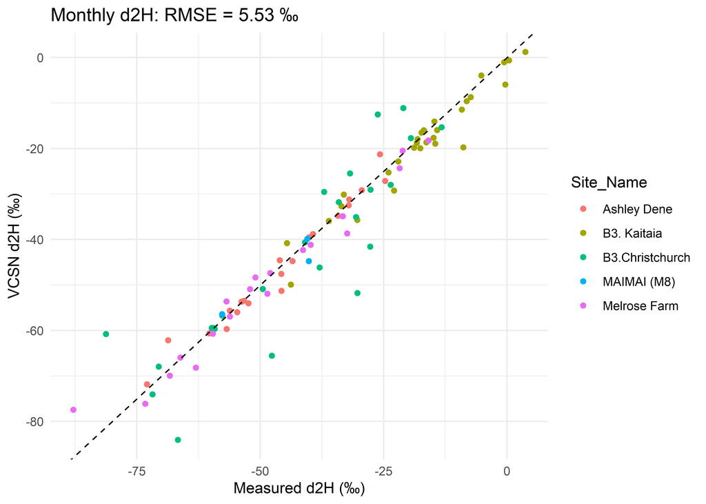

```r
print(d2H_plot)
```

Line plots

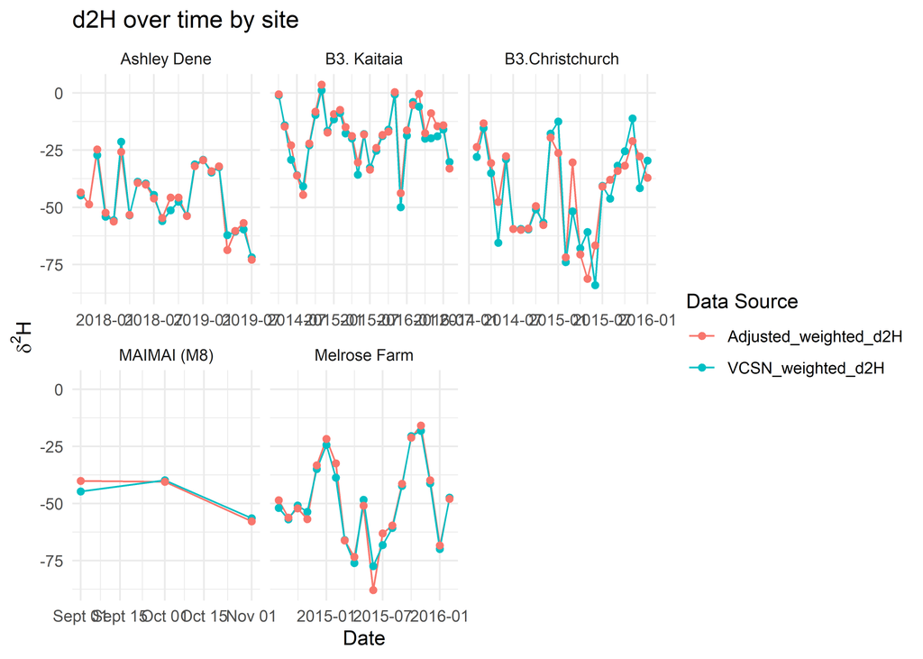

```r
library(tidyverse)
library(lubridate)

# Convert data to long format for d2H
df_d2H_long <- filtered_df %>%
  select(Site_Name, year_month, VCSN_weighted_d2H, Adjusted_weighted_d2H) %>%
  pivot_longer(cols = c(VCSN_weighted_d2H, Adjusted_weighted_d2H),
               names_to = "Source",
               values_to = "d2H")

# Plot d2H through time faceted by Site_Name
p_d2H <- ggplot(df_d2H_long, aes(x = year_month, y = d2H, color = Source)) +
  geom_line() +
  geom_point() +
  facet_wrap(~ Site_Name, scales = "free_x") +
  labs(title = "d2H over time by site",
       x = "Date",
       y = expression(delta^{2}*H),
       color = "Data Source") +
  theme_minimal()

# Convert data to long format for d18O
df_d18O_long <- filtered_df %>%
  select(Site_Name, year_month, VCSN_weighted_d18O, Adjusted_weighted_d18O) %>%
  pivot_longer(cols = c(VCSN_weighted_d18O, Adjusted_weighted_d18O),
               names_to = "Source",
               values_to = "d18O")

# Plot d18O through time faceted by Site_Name
p_d18O <- ggplot(df_d18O_long, aes(x = year_month, y = d18O, color = Source)) +
  geom_line() +
  geom_point() +
  facet_wrap(~ Site_Name, scales = "free_x") +
  labs(title = expression(delta^{18}*O~"over time by site"),
       x = "Date",
       y = expression(delta^{18}*O),
       color = "Data Source") +
  theme_minimal()

# Print the plots
print(p_d2H)
```

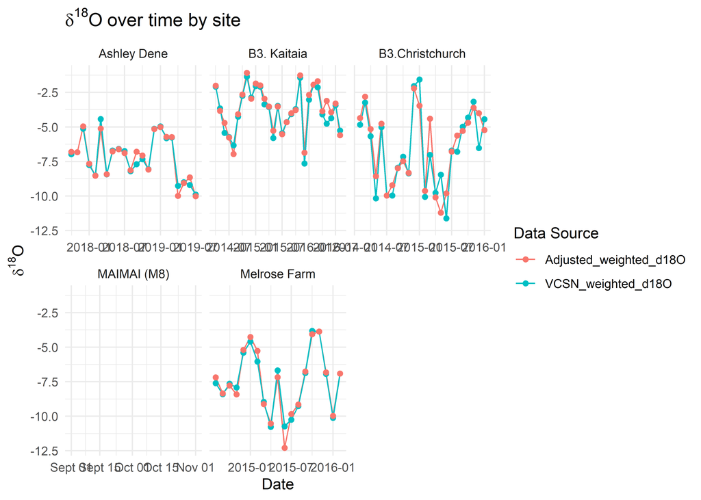

```r
print(p_d18O)
```

# 14 Test for effects of collection date ‘frame shifts’ away from a full month sampling date

```r
library(dplyr)
library(lubridate)
library(tidyr)

# Step 1: Calendar-month weighted isotope values (true)
monthly_true <- daily_expanded %>%
  filter(!is.na(d2H) | !is.na(d18O)) %>%
  mutate(
    data_month = floor_date(date, "month"),
    Collection_date = ceiling_date(date, "month")
  ) %>%
  group_by(Site_Name, data_month, Collection_date) %>%
  summarise(
    weighted_d2H = if (all(is.na(d2H))) NA else sum(Precipitation_mm * d2H, na.rm = TRUE) / sum(Precipitation_mm[!is.na(d2H)], na.rm = TRUE),
    weighted_d18O = if (all(is.na(d18O))) NA else sum(Precipitation_mm * d18O, na.rm = TRUE) / sum(Precipitation_mm[!is.na(d18O)], na.rm = TRUE),
    .groups = "drop"
  ) %>%
  mutate(
    year_month = Collection_date,
    Start_date = data_month
  ) %>%
  select(Site_Name, year_month, weighted_d2H, weighted_d18O)

# Step 2: Add one month before and after per site
monthly_padded <- monthly_true %>%
  group_by(Site_Name) %>%
  summarise(
    start = min(year_month) %m-% months(1),
    end = max(year_month) %m+% months(1),
    .groups = "drop"
  ) %>%
  rowwise() %>%
  mutate(
    full_months = list(seq.Date(start, end, by = "1 month"))
  ) %>%
  unnest(cols = c(full_months)) %>%
  rename(year_month = full_months) %>%
  mutate(
    Collection_date = year_month,
    Start_date = year_month %m-% months(1)
  ) %>%
  select(Site_Name, year_month, Start_date, Collection_date) %>%
  left_join(monthly_true, by = c("Site_Name", "year_month")) %>%
  arrange(Site_Name, year_month)

## Add in frame shift columns

monthly_padded <- monthly_padded %>%
  mutate(
    Start_date5 = Start_date + days(5),
    Collection_date5 = Collection_date + days(5),
    Start_date10 = Start_date + days(10),
    Collection_date10 = Collection_date + days(10),
    Start_date15 = Start_date + days(15),
    Collection_date15 = Collection_date + days(15)
  )
```

### 14.0.1 Join new date ranges back to daily dataset and calculate frame-shifted values

```r
library(dplyr)
library(purrr)

site_list <- unique(monthly_padded$Site_Name)

# Function to compute shifted values for one site
compute_shifts <- function(site_name) {
  df_site <- monthly_padded %>% filter(Site_Name == site_name)

  df_site <- df_site %>%
    rowwise() %>%
    mutate(
      d2H_shift5 = {
        df <- daily_expanded %>%
          filter(
            Site_Name == site_name,
            date >= Start_date5,
            date <= Collection_date5,
            !is.na(d2H)
          )
        if (nrow(df) == 0) NA_real_ else sum(df$Precipitation_mm * df$d2H) / sum(df$Precipitation_mm)
      },
      d18O_shift5 = {
        df <- daily_expanded %>%
          filter(
            Site_Name == site_name,
            date >= Start_date5,
            date <= Collection_date5,
            !is.na(d18O)
          )
        if (nrow(df) == 0) NA_real_ else sum(df$Precipitation_mm * df$d18O) / sum(df$Precipitation_mm)
      }
    ) %>%
    ungroup()

  return(df_site)
}

# Apply the function to all sites
monthly_padded <- map_dfr(site_list, compute_shifts)

monthly_padded$d2H_shift10 <- NA_real_
monthly_padded$d18O_shift10 <- NA_real_

for (site in unique(monthly_padded$Site_Name)) {
  site_rows <- monthly_padded$Site_Name == site
  for (i in which(site_rows)) {
    start <- monthly_padded$Start_date10[i]
    end <- monthly_padded$Collection_date10[i]

    df <- daily_expanded %>%
      filter(Site_Name == site, date >= start, date <= end, !is.na(d2H))

    if (nrow(df) > 0) {
      monthly_padded$d2H_shift10[i] <- sum(df$Precipitation_mm * df$d2H) / sum(df$Precipitation_mm)
    }

    df <- daily_expanded %>%
      filter(Site_Name == site, date >= start, date <= end, !is.na(d18O))

    if (nrow(df) > 0) {
      monthly_padded$d18O_shift10[i] <- sum(df$Precipitation_mm * df$d18O) / sum(df$Precipitation_mm)
    }
  }
}

monthly_padded$d2H_shift15 <- NA_real_
monthly_padded$d18O_shift15 <- NA_real_

for (site in unique(monthly_padded$Site_Name)) {
  site_rows <- monthly_padded$Site_Name == site
  for (i in which(site_rows)) {
    start <- monthly_padded$Start_date15[i]
    end <- monthly_padded$Collection_date15[i]

    df <- daily_expanded %>%
      filter(Site_Name == site, date >= start, date <= end, !is.na(d2H))

    if (nrow(df) > 0) {
      monthly_padded$d2H_shift15[i] <- sum(df$Precipitation_mm * df$d2H) / sum(df$Precipitation_mm)
    }

    df <- daily_expanded %>%
      filter(Site_Name == site, date >= start, date <= end, !is.na(d18O))

    if (nrow(df) > 0) {
      monthly_padded$d18O_shift15[i] <- sum(df$Precipitation_mm * df$d18O) / sum(df$Precipitation_mm)
    }
  }
}
```

### 14.0.2 Now make a daily dataframe from the monthly weighted data

```r
library(dplyr)
library(tidyr)
daily_weighted <- monthly_padded %>%
  rowwise() %>%
  mutate(date_seq = list(seq.Date(Start_date, Collection_date - 1, by = "day"))) %>%
  unnest(date_seq) %>%
  dplyr::select(Site_Name, Date = date_seq, weighted_d2H, weighted_d18O)

# 5-day shifted
daily_weighted_5 <- monthly_padded %>%
  rowwise() %>%
  mutate(date_seq = list(seq.Date(Start_date5, Collection_date5 - 1, by = "day"))) %>%
  unnest(date_seq) %>%
  dplyr::select(Site_Name, Date = date_seq, d2H = d2H_shift5, d18O = d18O_shift5)

# 10-day shifted
daily_weighted_10 <- monthly_padded %>%
  rowwise() %>%
  mutate(date_seq = list(seq.Date(Start_date10, Collection_date10 - 1, by = "day"))) %>%
  unnest(date_seq) %>%
  dplyr::select(Site_Name, Date = date_seq, d2H = d2H_shift10, d18O = d18O_shift10)

# 15-day shifted
daily_weighted_15 <- monthly_padded %>%
  rowwise() %>%
  mutate(date_seq = list(seq.Date(Start_date15, Collection_date15 - 1, by = "day"))) %>%
  unnest(date_seq) %>%
  dplyr::select(Site_Name, Date = date_seq, d2H = d2H_shift15, d18O = d18O_shift15)


library(dplyr)

# First, rename the isotope columns in the shifted datasets
daily_weighted_5_renamed <- daily_weighted_5 %>%
  rename(d2H_5 = d2H,
         d18O_5 = d18O)

daily_weighted_10_renamed <- daily_weighted_10 %>%
  rename(d2H_10 = d2H,
         d18O_10 = d18O)

daily_weighted_15_renamed <- daily_weighted_15 %>%
  rename(d2H_15 = d2H,
         d18O_15 = d18O)

# Start with daily_weighted, then left_join the others by Site_Name and Date
combined_daily <- daily_weighted %>%
  left_join(daily_weighted_5_renamed,  by = c("Site_Name", "Date")) %>%
  left_join(daily_weighted_10_renamed, by = c("Site_Name", "Date")) %>%
  left_join(daily_weighted_15_renamed, by = c("Site_Name", "Date"))

# View result
glimpse(combined_daily)
```

```
Rows: 3,378
Columns: 10
$ Site_Name     <chr> "Ashley Dene", "Ashley Dene", "Ashley Dene", "Ashley Den…
$ Date          <date> 2017-09-01, 2017-09-02, 2017-09-03, 2017-09-04, 2017-09…
$ weighted_d2H  <dbl> NA, NA, NA, NA, NA, NA, NA, NA, NA, NA, NA, NA, NA, NA, …
$ weighted_d18O <dbl> NA, NA, NA, NA, NA, NA, NA, NA, NA, NA, NA, NA, NA, NA, …
$ d2H_5         <dbl> NA, NA, NA, NA, NA, NA, NA, NA, NA, NA, NA, NA, NA, NA, …
$ d18O_5        <dbl> NA, NA, NA, NA, NA, NA, NA, NA, NA, NA, NA, NA, NA, NA, …
$ d2H_10        <dbl> NA, NA, NA, NA, NA, NA, NA, NA, NA, NA, -43.83, -43.83, …
$ d18O_10       <dbl> NA, NA, NA, NA, NA, NA, NA, NA, NA, NA, -6.92, -6.92, -6…
$ d2H_15        <dbl> NA, NA, NA, NA, NA, NA, NA, NA, NA, NA, NA, NA, NA, NA, …
$ d18O_15       <dbl> NA, NA, NA, NA, NA, NA, NA, NA, NA, NA, NA, NA, NA, NA, …
```

Now reattach this to the original daily dataframe

```r
library(dplyr)

# Make sure the date columns are of the same name and type
combined_daily_renamed <- combined_daily %>%
  rename(date = Date)

# Now join the new data to daily_expanded
daily_expanded_joined <- daily_expanded %>%
  left_join(combined_daily_renamed %>%
              select(Site_Name, date, weighted_d2H, weighted_d18O,
                     d2H_5, d18O_5, d2H_10, d18O_10, d2H_15, d18O_15),
            by = c("Site_Name", "date"))
```

### 14.0.3 Put together a dataframe of ‘frame shifted’ dates

```r
monthly_final <- daily_expanded_joined %>%
  # keep any row that has at least one isotope value
  filter(
    !is.na(d2H) | !is.na(d18O) |
    !is.na(d2H_5) | !is.na(d18O_5) |
    !is.na(d2H_10) | !is.na(d18O_10) |
    !is.na(d2H_15) | !is.na(d18O_15)
  ) %>%
  mutate(
    data_month     = floor_date(date,  "month"),
    Collection_date = ceiling_date(date, "month")
  ) %>%
  group_by(Site_Name, data_month, Collection_date) %>%
  summarise(
    # — True daily isotopes
    weighted_d2H        = if (all(is.na(d2H)))       NA_real_ else sum(Precipitation_mm * d2H,    na.rm = TRUE) / sum(Precipitation_mm[!is.na(d2H)],    na.rm = TRUE),
    weighted_d18O       = if (all(is.na(d18O)))      NA_real_ else sum(Precipitation_mm * d18O,   na.rm = TRUE) / sum(Precipitation_mm[!is.na(d18O)],   na.rm = TRUE),
    # — Check (using already-weighted daily values)
    weighted_d2H_check  = if (all(is.na(weighted_d2H)))  NA_real_ else sum(Precipitation_mm * weighted_d2H,  na.rm = TRUE) / sum(Precipitation_mm[!is.na(weighted_d2H)],  na.rm = TRUE),
    weighted_d18O_check = if (all(is.na(weighted_d18O))) NA_real_ else sum(Precipitation_mm * weighted_d18O, na.rm = TRUE) / sum(Precipitation_mm[!is.na(weighted_d18O)], na.rm = TRUE),

    # — 5‑day shifted
    weighted_d2H_5      = if (all(is.na(d2H_5)))     NA_real_ else sum(Precipitation_mm * d2H_5,   na.rm = TRUE) / sum(Precipitation_mm[!is.na(d2H_5)],   na.rm = TRUE),
    weighted_d18O_5     = if (all(is.na(d18O_5)))    NA_real_ else sum(Precipitation_mm * d18O_5,  na.rm = TRUE) / sum(Precipitation_mm[!is.na(d18O_5)],  na.rm = TRUE),

    # — 10‑day shifted
    weighted_d2H_10     = if (all(is.na(d2H_10)))    NA_real_ else sum(Precipitation_mm * d2H_10,  na.rm = TRUE) / sum(Precipitation_mm[!is.na(d2H_10)],  na.rm = TRUE),
    weighted_d18O_10    = if (all(is.na(d18O_10)))   NA_real_ else sum(Precipitation_mm * d18O_10, na.rm = TRUE) / sum(Precipitation_mm[!is.na(d18O_10)], na.rm = TRUE),

    # — 15‑day shifted
    weighted_d2H_15     = if (all(is.na(d2H_15)))    NA_real_ else sum(Precipitation_mm * d2H_15,  na.rm = TRUE) / sum(Precipitation_mm[!is.na(d2H_15)],  na.rm = TRUE),
    weighted_d18O_15    = if (all(is.na(d18O_15)))   NA_real_ else sum(Precipitation_mm * d18O_15, na.rm = TRUE) / sum(Precipitation_mm[!is.na(d18O_15)], na.rm = TRUE),

    .groups = "drop"
  ) %>%
  # finally label your "month" and "start"
  mutate(
    year_month = Collection_date,
    Start_date = data_month
  ) %>%
  select(
    Site_Name, year_month, Start_date,
    weighted_d2H,    weighted_d18O,
    weighted_d2H_check,    weighted_d18O_check,
    weighted_d2H_5,  weighted_d18O_5,
    weighted_d2H_10, weighted_d18O_10,
    weighted_d2H_15, weighted_d18O_15
  )
```

### 14.0.4 Plotting and RMSE calcs for date-shifting effects

### 14.0.5 Reshape monthly_final for plotting

This reformats the wide structure into a tidy long format with labeled shift windows:

```r
library(tidyr)
library(dplyr)
library(ggplot2)

comparison_long <- monthly_final %>%
  select(Site_Name, year_month, starts_with("weighted_d")) %>%
  pivot_longer(
    cols = starts_with("weighted_d"),
    names_to = "parameter",
    values_to = "value"
  ) %>%
  mutate(
    isotope = case_when(
      grepl("d2H", parameter) ~ "δ²H",
      grepl("d18O", parameter) ~ "δ¹⁸O"
    ),
    type = case_when(
      parameter %in% c("weighted_d2H", "weighted_d18O") ~ "Calendar month",
      parameter %in% c("weighted_d2H_5", "weighted_d18O_5") ~ "5-day shift",
      parameter %in% c("weighted_d2H_10", "weighted_d18O_10") ~ "10-day shift",
      parameter %in% c("weighted_d2H_15", "weighted_d18O_15") ~ "15-day shift",
      grepl("check", parameter) ~ NA_character_,
      TRUE ~ NA_character_
    ),
    type = factor(type, levels = c("Calendar month", "5-day shift", "10-day shift", "15-day shift"))
  ) %>%
  filter(!is.na(type)) %>%
  mutate(Site_Name = factor(Site_Name, levels = c(setdiff(unique(Site_Name), "MAIMAI (M8)"), "MAIMAI (M8)"))) %>%
  filter(!(Site_Name == "MAIMAI (M8)" & isotope == "δ¹⁸O"))
```

### 14.0.6 Plot the isotope values by shift type

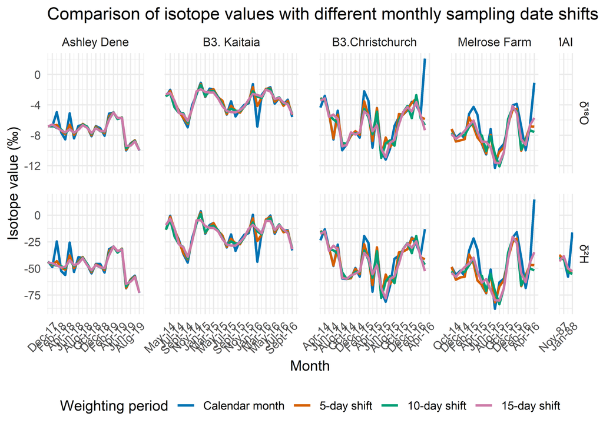

```r
ggplot(comparison_long, aes(x = year_month, y = value, color = type)) +
  geom_line(size = 1) +
  facet_grid(isotope ~ Site_Name, scales = "free", space = "free_x") +
  labs(
    x = "Month",
    y = "Isotope value (‰)",
    color = "Weighting period",
    title = "Comparison of isotope values with different monthly sampling date shifts"
  ) +
  scale_x_date(
    date_labels = "%b-%y",
    date_breaks = "2 months",
    expand = expansion(mult = c(0.01, 0.05))
  ) +
  scale_color_manual(
    values = c(
      "Calendar month" = "#0072B2",
      "5-day shift" = "#D55E00",
      "10-day shift" = "#009E73",
      "15-day shift" = "#CC79A7"
    )
  ) +
  theme_minimal(base_size = 12) +
  theme(
    axis.text.x = element_text(angle = 45, hjust = 1),
    strip.text = element_text(size = 10),
    legend.position = "bottom",
    panel.spacing = unit(1.2, "lines")
  )
```

### 14.0.7 Calculate RMSE values

This compares each shifted series against the calendar-month baseline for both δ²H and δ¹⁸O

```r
library(Metrics)
library(dplyr)
library(tidyr)

rmse_results <- comparison_long %>%
  pivot_wider(
    id_cols = c(Site_Name, year_month, isotope),
    names_from = type,
    values_from = value
  ) %>%
  group_by(Site_Name, isotope) %>%
  summarise(
    RMSE_5  = rmse(`Calendar month`, `5-day shift`),
    RMSE_10 = rmse(`Calendar month`, `10-day shift`),
    RMSE_15 = rmse(`Calendar month`, `15-day shift`),
    .groups = "drop"
  )

# Add overall RMSE (pooled)
overall_rmse <- comparison_long %>%
  pivot_wider(
    id_cols = c(Site_Name, year_month, isotope),
    names_from = type,
    values_from = value
  ) %>%
  group_by(isotope) %>%
  summarise(
    Site_Name = "Overall (pooled)",
    RMSE_5  = rmse(`Calendar month`, `5-day shift`),
    RMSE_10 = rmse(`Calendar month`, `10-day shift`),
    RMSE_15 = rmse(`Calendar month`, `15-day shift`),
    .groups = "drop"
  )

# Optional: overall mean of site-level RMSEs
mean_rmse <- rmse_results %>%
  group_by(isotope) %>%
  summarise(
    Site_Name = "Mean of site RMSEs",
    RMSE_5  = mean(RMSE_5, na.rm = TRUE),
    RMSE_10 = mean(RMSE_10, na.rm = TRUE),
    RMSE_15 = mean(RMSE_15, na.rm = TRUE),
    .groups = "drop"
  )

# Combine
rmse_results_combined <- bind_rows(rmse_results, mean_rmse, overall_rmse)

print(rmse_results_combined)
```

```
# A tibble: 13 × 5
   Site_Name          isotope RMSE_5 RMSE_10 RMSE_15
   <chr>              <chr>    <dbl>   <dbl>   <dbl>
 1 Ashley Dene        δ²H      5.09    6.62    6.87
 2 Ashley Dene        δ¹⁸O     0.541   0.721   0.753
 3 B3. Kaitaia        δ²H      4.19    6.23    7.24
 4 B3. Kaitaia        δ¹⁸O     0.572   0.846   0.953
 5 B3.Christchurch    δ²H      9.52   11.9    12.0
 6 B3.Christchurch    δ¹⁸O     1.86    2.22    2.29
 7 Melrose Farm       δ²H     17.7    19.1    15.5
 8 Melrose Farm       δ¹⁸O     1.81    2.01    1.62
 9 MAIMAI (M8)        δ²H     18.7    19.6    18.7
10 Mean of site RMSEs δ²H     11.0    12.7    12.0
11 Mean of site RMSEs δ¹⁸O     1.20    1.45    1.40
12 Overall (pooled)   δ²H     10.4    12.0    11.1
13 Overall (pooled)   δ¹⁸O     1.32    1.56    1.52
```

# 15 Write final ‘Stage 1’ data outputs to an excel file

```r
library(writexl)

# Function to clean illegal XML characters
clean_illegal_chars <- function(df) {
  df[] <- lapply(df, function(x) {
    if (is.character(x)) {
      # Force encoding to UTF-8 and replace invalid characters
      x <- iconv(x, from = "", to = "UTF-8", sub = "")
      # Remove characters not allowed in XML 1.0
      x <- gsub("[^\x09\x0A\x0D\x20-\x7F]", "", x)
    }
    return(x)
  })
  return(df)
}


# Clean each dataframe
Lookup_filtered_clean <- clean_illegal_chars(Lookup_filtered)
Full_database_clean <- clean_illegal_chars(Full_database)
monthly_weighted_clean <- clean_illegal_chars(monthly_weighted)
summary_by_project_clean <- clean_illegal_chars(summary_by_project)

# Write cleaned dataframes to Excel
write_xlsx(
  list(
    "Lookup Table" = Lookup_filtered_clean,
    "Subdaily data" = ddata,
    "Daily and greater" = Full_database_clean,
    "Monthly database" = monthly_weighted_clean,
    "Datatypes" = summary_by_project_clean
  ),
  path = "output/Processesed_database.xlsx"
)
```